# Annotation Quality AlphaGenome Calibration

test_susine

2026-04-16

Summary: Uses the active `test_susine` simulation helpers to calibrate the annotation-generation parameters `annotation_r2` and `inflate_match` against AlphaGenome-style expression benchmarks. This workbook pools simulated variants across repeated `susie2_oligogenic` loci, states the paper-side benchmark definitions explicitly, and reports three heatmaps over the full `annotation_r2 x inflate_match` grid.

# 1 Overview

This workbook separates the annotation-quality calibration problem from the `tau` study.

For each simulated locus:

- `b` is drawn from the fixed-tier `susie2_oligogenic` architecture;
- `a` is drawn from the annotation simulator over a grid of `annotation_r2` and `inflate_match`;
- the causality positives are the top `p_score_causality` true causal SNPs by `|beta|`;
- the rank-correlation set is the top `p_score_rank` true causal SNPs by `|beta|`;
- the causality negatives are the true null SNPs only.

The main outputs are:

- pooled equivalent causality `auROC`, obtained by converting pooled sparse-vs-null AUPRC to the balanced-case AUROC under an equal-variance Gaussian score model;
- pooled signed Spearman correlation on the rank-correlation set;
- pooled unsigned Spearman correlation on the rank-correlation set.

The intended use is:

- use the causality panel mainly to reason about `inflate_match`;
- use the signed and unsigned rank-correlation panels mainly to reason about `annotation_r2`;
- then record a simple working calibration choice for downstream studies.

# 2 Setup

```r
here::i_am("vignettes/one_off_validations/annotation_quality_alphagenome_calibration.Rmd")
devtools::load_all(here::here(), quiet = TRUE)

library(dplyr)
library(ggplot2)
library(knitr)
library(purrr)
library(scales)
library(tidyr)
```

# 3 User Options

```r
p <- 1000L
n_beta_draws <- 600L
p_score_causality <- 3L
p_score_rank <- 23L

annotation_r2_grid <- seq(0, 1, by = 0.1)
inflate_match_grid <- seq(0, 1, by = 0.1)

effect_sd <- 1
working_annotation_r2 <- 0.30
working_inflate_match_range <- c(0.95, 1.00)

cat("architecture = susie2_oligogenic\n")
```

```
## architecture = susie2_oligogenic
```

```r
cat("p =", p, "\n")
```

```
## p = 1000
```

```r
cat("beta draws =", n_beta_draws, "\n")
```

```
## beta draws = 600
```

```r
cat("p_score_causality =", p_score_causality, "\n")
```

```
## p_score_causality = 3
```

```r
cat("p_score_rank =", p_score_rank, "\n")
```

```
## p_score_rank = 23
```

```r
cat("annotation_r2 grid =", paste(annotation_r2_grid, collapse = ", "), "\n")
```

```
## annotation_r2 grid = 0, 0.1, 0.2, 0.3, 0.4, 0.5, 0.6, 0.7, 0.8, 0.9, 1
```

```r
cat("inflate_match grid =", paste(inflate_match_grid, collapse = ", "), "\n")
```

```
## inflate_match grid = 0, 0.1, 0.2, 0.3, 0.4, 0.5, 0.6, 0.7, 0.8, 0.9, 1
```

```r
cat("working annotation_r2 =", working_annotation_r2, "\n")
```

```
## working annotation_r2 = 0.3
```

```r
cat(
  "working inflate_match range =",
  paste(signif(working_inflate_match_range, 3), collapse = " to "),
  "\n"
)
```

```
## working inflate_match range = 0.95 to 1
```

# 4 AlphaGenome Targets

The AlphaGenome paper evaluates three eQTL tasks that matter for this calibration:

1. `eQTL coefficient` Evaluated on fine-mapped GTEx eQTL SNVs. Each example is a unique `variant / gene / tissue` tuple, and the observed target is the SuSiE `beta posterior`. In the main scatter for 17,675 fine-mapped GTEx eQTL tuples, the paper reports:
   - signed Spearman `rho = 0.50`
   - unsigned Spearman `rho = 0.10`

   In the main text, the tissue-weighted mean signed coefficient performance is reported as `0.49`.
2. `eQTL sign` Also evaluated on the fine-mapped eQTL set. This is a direction-of-effect task on true eQTLs only: the signed AlphaGenome score is used to distinguish positive from negative observed eQTL effects. The main text reports a tissue-weighted mean sign `auROC = 0.80`.
3. `eQTL causality` This is the causal-versus-noncausal classification task. The paper text describes this as distinguishing fine-mapped eQTLs from distance-matched variants. In the benchmark construction, high-confidence positives are SuSiE `PIP >= 0.9` and noncausal controls are `PIP < 0.01`. The main headline values are:
   - zero-shot causality `auROC = 0.71`
   - supervised random-forest causality `auROC = 0.80`

The current workbook directly targets the causality and coefficient-style benchmarks. We do not currently add a separate sign-`auROC` heatmap because the signed Spearman panel already captures whether the simulated annotation tracks the sign and relative size of the true causal effects, but the AlphaGenome sign value `0.80` remains a useful qualitative reference point.

These benchmark descriptions and values come from the main AlphaGenome paper and supplementary benchmark construction notes, especially the GTEx eQTL coefficient, sign, and causality sections.

# 5 Helpers

```r
`%||%` <- function(x, y) {
  if (is.null(x)) y else x
}

fmt_num <- function(x) {
  formatC(x, format = "f", digits = 2)
}

top_k_causal_idx <- function(beta, k) {
  beta <- as.numeric(beta)
  causal_idx <- which(beta != 0)
  if (!length(causal_idx)) {
    return(integer(0))
  }
  n_top <- min(as.integer(k), length(causal_idx))
  causal_idx[order(abs(beta[causal_idx]), decreasing = TRUE)[seq_len(n_top)]]
}

simulate_priors_zero_safe <- function(beta,
                                      annotation_r2,
                                      inflate_match,
                                      base_sigma2 = NULL,
                                      effect_sd = NULL,
                                      seed = NULL) {
  if (!is.null(seed) && is.finite(seed)) {
    set.seed(as.integer(seed))
  }

  p <- length(beta)
  causal_idx <- which(beta != 0)
  noncausal_idx <- setdiff(seq_len(p), causal_idx)

  if (is.null(effect_sd) || !is.finite(effect_sd) || effect_sd <= 0) {
    effect_sd <- sqrt(max(stats::var(beta[causal_idx]), stats::var(beta), 1))
  }

  if (is.null(annotation_r2) || is.na(annotation_r2)) annotation_r2 <- 0
  if (is.null(inflate_match) || is.na(inflate_match)) inflate_match <- 0
  annotation_r2 <- pmin(pmax(annotation_r2, 0), 1)
  inflate_match <- max(inflate_match, 0)

  causal_var <- stats::var(beta[causal_idx])
  if (is.na(causal_var) || causal_var == 0) {
    causal_var <- effect_sd^2
  }

  mu_0 <- numeric(p)
  if (length(causal_idx)) {
    causal_beta <- as.numeric(beta[causal_idx])
    causal_mean <- mean(causal_beta)
    causal_centered <- causal_beta - causal_mean
    causal_scale <- sqrt(mean(causal_centered^2))
    if (!is.finite(causal_scale) || causal_scale <= 0) {
      causal_scale <- sqrt(causal_var)
    }

    if (length(causal_idx) == 1L || !is.finite(causal_scale) || causal_scale <= 0) {
      mu_0[causal_idx] <- causal_beta
    } else {
      signal_unit <- causal_centered / causal_scale
      noise_unit <- draw_centered_noise(
        length(causal_idx),
        target_scale = 1,
        orthogonal_to = signal_unit
      )
      causal_annotation_centered <- causal_scale * (
        sqrt(annotation_r2) * signal_unit +
          sqrt(1 - annotation_r2) * noise_unit
      )
      mu_0[causal_idx] <- causal_mean + causal_annotation_centered
    }
  }

  theoretical_causal_mu0_var <- if (length(causal_idx) > 1L) {
    mean((mu_0[causal_idx] - mean(mu_0[causal_idx]))^2)
  } else {
    causal_var
  }

  if (length(noncausal_idx)) {
    if (inflate_match <= 0) {
      mu_0[noncausal_idx] <- 0
    } else {
      noncausal_scale <- sqrt(inflate_match) * sqrt(theoretical_causal_mu0_var)
      mu_0[noncausal_idx] <- draw_centered_noise(
        length(noncausal_idx),
        target_scale = noncausal_scale
      )
    }
  }

  observed_r2 <- NA_real_
  if (length(causal_idx) > 1 &&
      stats::sd(beta[causal_idx]) > 0 &&
      stats::sd(mu_0[causal_idx]) > 0) {
    observed_r2 <- stats::cor(mu_0[causal_idx], beta[causal_idx])^2
  }

  base_sigma2 <- base_sigma2 %||% causal_var
  if (is.na(base_sigma2) || base_sigma2 <= 0) {
    base_sigma2 <- effect_sd^2
  }

  sigma_0_2 <- rep(base_sigma2, p)

  list(
    mu_0 = mu_0,
    sigma_0_2 = sigma_0_2,
    observed_r2 = observed_r2
  )
}

pooled_spearman <- function(annotation_list, beta_list, positive_idx_list, use_abs = FALSE) {
  pooled_annotation <- unlist(
    purrr::map2(annotation_list, positive_idx_list, ~ as.numeric(.x)[.y]),
    use.names = FALSE
  )
  pooled_beta <- unlist(
    purrr::map2(beta_list, positive_idx_list, ~ as.numeric(.x)[.y]),
    use.names = FALSE
  )

  if (use_abs) {
    pooled_annotation <- abs(pooled_annotation)
    pooled_beta <- abs(pooled_beta)
  }

  if (length(pooled_annotation) < 2L ||
      length(unique(pooled_annotation)) < 2L ||
      length(unique(pooled_beta)) < 2L) {
    return(NA_real_)
  }

  suppressWarnings(
    stats::cor(pooled_annotation, pooled_beta, method = "spearman")
  )
}

pooled_average_precision <- function(annotation_list, positive_idx_list, null_idx_list) {
  positive_scores <- unlist(
    purrr::map2(annotation_list, positive_idx_list, ~ abs(as.numeric(.x)[.y])),
    use.names = FALSE
  )
  null_scores <- unlist(
    purrr::map2(annotation_list, null_idx_list, ~ abs(as.numeric(.x)[.y])),
    use.names = FALSE
  )

  scores <- c(positive_scores, null_scores)
  labels <- c(rep.int(1L, length(positive_scores)), rep.int(0L, length(null_scores)))

  if (!length(scores) || !sum(labels)) {
    return(NA_real_)
  }

  auprc_average_precision(scores = scores, labels = labels)
}

ap_from_dprime <- function(dprime,
                           prevalence,
                           lo = -8,
                           hi = 12,
                           n = 4000L) {
  threshold <- seq(lo, hi, length.out = n + 1L)
  true_positive_rate <- 1 - stats::pnorm(threshold, mean = dprime, sd = 1)
  false_positive_rate <- 1 - stats::pnorm(threshold, mean = 0, sd = 1)
  recall <- true_positive_rate
  precision <- prevalence * true_positive_rate /
    (prevalence * true_positive_rate + (1 - prevalence) * false_positive_rate)
  precision[is.nan(precision)] <- 1
  sum(0.5 * (precision[-1] + precision[-length(precision)]) * abs(diff(recall)))
}

build_ap_to_balanced_auroc <- function(prevalence,
                                       d_max = 6,
                                       d_grid_length = 1201L,
                                       integration_points = 4000L) {
  d_grid <- seq(0, d_max, length.out = d_grid_length)
  ap_grid <- vapply(
    d_grid,
    ap_from_dprime,
    numeric(1),
    prevalence = prevalence,
    n = integration_points
  )
  ap_grid <- cummax(ap_grid)

  function(observed_ap) {
    if (!is.finite(observed_ap) || observed_ap <= prevalence) {
      return(0.5)
    }

    clamped_ap <- min(observed_ap, max(ap_grid))
    dprime <- stats::approx(
      x = ap_grid,
      y = d_grid,
      xout = clamped_ap,
      rule = 2,
      ties = "ordered"
    )$y
    stats::pnorm(dprime / sqrt(2))
  }
}

ideal_text_color <- function(fill_hex) {
  rgb <- grDevices::col2rgb(fill_hex)
  luminance <- 0.2126 * rgb[1, ] + 0.7152 * rgb[2, ] + 0.0722 * rgb[3, ]
  ifelse(luminance < 140, "white", "black")
}

plot_metric_heatmap <- function(summary_tbl,
                                value_col,
                                title,
                                subtitle,
                                fill_label,
                                option = "D",
                                limits = NULL,
                                digits = 2) {
  values <- summary_tbl[[value_col]]
  lims <- limits %||% range(values, na.rm = TRUE)
  if (!all(is.finite(lims))) {
    lims <- c(0, 1)
  }
  if (diff(lims) <= 0) {
    lims <- lims + c(-1e-6, 1e-6)
  }

  palette_values <- viridisLite::viridis(256, option = option, end = 0.98)
  fill_mapper <- scales::col_numeric(
    palette = palette_values,
    domain = lims,
    na.color = "#bdbdbd"
  )

  plot_tbl <- summary_tbl %>%
    dplyr::mutate(
      metric_value = .data[[value_col]],
      fill_hex = fill_mapper(.data$metric_value),
      text_color = ideal_text_color(.data$fill_hex),
      label = sprintf(paste0("%.", digits, "f"), .data$metric_value)
    )

  ggplot(plot_tbl, aes(x = .data$annotation_r2_f, y = .data$inflate_match_f, fill = .data$metric_value)) +
    geom_tile(color = "white", linewidth = 0.5) +
    geom_text(aes(label = .data$label, color = .data$text_color), size = 4.2, fontface = "bold") +
    scale_color_identity() +
    scale_fill_gradientn(colors = palette_values, limits = lims, oob = scales::squish) +
    labs(
      title = title,
      subtitle = subtitle,
      x = "annotation_r2",
      y = "inflate_match",
      fill = fill_label
    ) +
    theme_minimal(base_size = 12) +
    theme(
      panel.grid = element_blank(),
      axis.text.x = element_text(angle = 0, hjust = 0.5)
    )
}
```

# 6 Simulate Beta Draws

```r
beta_tbl <- tibble::tibble(
  beta_id = seq_len(n_beta_draws),
  beta_seed = 10000L + seq_len(n_beta_draws)
) %>%
  dplyr::mutate(
    effects = purrr::map(
      .data$beta_seed,
      ~ simulate_effect_sizes_susie2_oligogenic(
        p = p,
        seed = .x
      )
    ),
    beta = purrr::map(.data$effects, "beta"),
    causal_idx = purrr::map(.data$effects, "causal_idx"),
    effect_tier = purrr::map(.data$effects, "effect_tier"),
    sparse_idx = purrr::map(.data$effect_tier, ~ which(.x == "sparse")),
    positive_idx_causality = purrr::map(.data$beta, top_k_causal_idx, k = p_score_causality),
    positive_idx_rank = purrr::map(.data$beta, top_k_causal_idx, k = p_score_rank),
    null_idx = purrr::map(.data$effect_tier, ~ which(.x == "none")),
    n_causal = purrr::map_int(.data$causal_idx, length),
    n_sparse = purrr::map_int(.data$sparse_idx, length),
    n_scored_causality = purrr::map_int(.data$positive_idx_causality, length),
    n_scored_rank = purrr::map_int(.data$positive_idx_rank, length),
    n_null = purrr::map_int(.data$null_idx, length)
  ) %>%
  dplyr::select(-.data$effects)

beta_tbl %>%
  dplyr::summarise(
    n_beta_draws = dplyr::n(),
    causal_per_draw = first(.data$n_causal),
    sparse_per_draw = first(.data$n_sparse),
    causality_positives_per_draw = first(.data$n_scored_causality),
    rank_variants_per_draw = first(.data$n_scored_rank),
    null_per_draw = first(.data$n_null)
  ) %>%
  knitr::kable(
    digits = 0,
    caption = "Architecture check and scored-set size under the fixed susie2_oligogenic simulation"
  )
```

Architecture check and scored-set size under the fixed susie2_oligogenic simulation

| n_beta_draws | causal_per_draw | sparse_per_draw | causality_positives_per_draw | rank_variants_per_draw | null_per_draw |
| --- | --- | --- | --- | --- | --- |
| 600 | 23 | 3 | 3 | 23 | 977 |

# 7 Simulate Annotations over the Grid

```r
settings_tbl <- tidyr::expand_grid(
  annotation_r2 = annotation_r2_grid,
  inflate_match = inflate_match_grid
) %>%
  dplyr::arrange(.data$annotation_r2, .data$inflate_match) %>%
  dplyr::mutate(
    setting_id = dplyr::row_number(),
    annotation_r2_f = factor(fmt_num(.data$annotation_r2), levels = fmt_num(annotation_r2_grid)),
    inflate_match_f = factor(fmt_num(.data$inflate_match), levels = fmt_num(inflate_match_grid))
  )

annotation_tbl <- tidyr::expand_grid(
  beta_id = beta_tbl$beta_id,
  setting_id = settings_tbl$setting_id
) %>%
  dplyr::left_join(beta_tbl, by = "beta_id") %>%
  dplyr::left_join(settings_tbl, by = "setting_id") %>%
  dplyr::mutate(
    annotation_seed = 500000L + .data$beta_id * 1000L + .data$setting_id,
    priors = purrr::pmap(
      list(.data$beta, .data$annotation_r2, .data$inflate_match, .data$annotation_seed),
      function(beta, annotation_r2, inflate_match, annotation_seed) {
        simulate_priors_zero_safe(
          beta = beta,
          annotation_r2 = annotation_r2,
          inflate_match = inflate_match,
          base_sigma2 = effect_sd^2,
          effect_sd = effect_sd,
          seed = annotation_seed
        )
      }
    ),
    annotation = purrr::map(.data$priors, "mu_0"),
    observed_r2 = purrr::map_dbl(.data$priors, "observed_r2")
  ) %>%
  dplyr::select(
    .data$beta_id,
    .data$setting_id,
    .data$annotation_r2,
    .data$inflate_match,
    .data$annotation_r2_f,
    .data$inflate_match_f,
    .data$beta,
    .data$annotation,
    .data$positive_idx_causality,
    .data$positive_idx_rank,
    .data$null_idx,
    .data$n_scored_causality,
    .data$n_scored_rank,
    .data$n_null,
    .data$observed_r2
  )

annotation_tbl %>%
  dplyr::group_by(.data$annotation_r2, .data$inflate_match) %>%
  dplyr::summarise(
    mean_observed_r2 = mean(.data$observed_r2, na.rm = TRUE),
    sd_observed_r2 = stats::sd(.data$observed_r2, na.rm = TRUE),
    .groups = "drop"
  ) %>%
  knitr::kable(
    digits = 3,
    caption = "Observed annotation R^2 by grid point"
  )
```

Observed annotation R^2 by grid point

| annotation_r2 | inflate_match | mean_observed_r2 | sd_observed_r2 |
| --- | --- | --- | --- |
| 0.0 | 0.0 | 0.0 | 0 |
| 0.0 | 0.1 | 0.0 | 0 |
| 0.0 | 0.2 | 0.0 | 0 |
| 0.0 | 0.3 | 0.0 | 0 |
| 0.0 | 0.4 | 0.0 | 0 |
| 0.0 | 0.5 | 0.0 | 0 |
| 0.0 | 0.6 | 0.0 | 0 |
| 0.0 | 0.7 | 0.0 | 0 |
| 0.0 | 0.8 | 0.0 | 0 |
| 0.0 | 0.9 | 0.0 | 0 |
| 0.0 | 1.0 | 0.0 | 0 |
| 0.1 | 0.0 | 0.1 | 0 |
| 0.1 | 0.1 | 0.1 | 0 |
| 0.1 | 0.2 | 0.1 | 0 |
| 0.1 | 0.3 | 0.1 | 0 |
| 0.1 | 0.4 | 0.1 | 0 |
| 0.1 | 0.5 | 0.1 | 0 |
| 0.1 | 0.6 | 0.1 | 0 |
| 0.1 | 0.7 | 0.1 | 0 |
| 0.1 | 0.8 | 0.1 | 0 |
| 0.1 | 0.9 | 0.1 | 0 |
| 0.1 | 1.0 | 0.1 | 0 |
| 0.2 | 0.0 | 0.2 | 0 |
| 0.2 | 0.1 | 0.2 | 0 |
| 0.2 | 0.2 | 0.2 | 0 |
| 0.2 | 0.3 | 0.2 | 0 |
| 0.2 | 0.4 | 0.2 | 0 |
| 0.2 | 0.5 | 0.2 | 0 |
| 0.2 | 0.6 | 0.2 | 0 |
| 0.2 | 0.7 | 0.2 | 0 |

[output cut: 91 more lines]

# 8 AlphaGenome-Style Calibration Logic

The point of this workbook is not to claim that our simulation is the same as the AlphaGenome evaluation. The point is to build a simple, explicit bridge from their benchmark definitions to our simulator, then use that bridge to pick reasonable annotation-generation parameters.

Our mapping is:

- AlphaGenome eQTL causality `->` our top-`p_score_causality` versus true-null task
- AlphaGenome eQTL coefficient `->` our pooled rank-correlation task on the top `p_score_rank` true causal SNPs

For the causality benchmark we use:

- positives = top `p_score_causality` true causal SNPs by `|beta|`;
- negatives = true null SNPs only;
- weaker true causal SNPs are excluded from the task.

This matches the intended analogy of high-confidence positives versus clear noncausal negatives, rather than folding weak true signals into the negative class.

For the coefficient-style benchmarks we use:

- the top `p_score_rank` true causal SNPs only;
- pooled signed Spearman between `a` and `beta`;
- pooled unsigned Spearman between `|a|` and `|beta|`.

This is meant to mimic the AlphaGenome coefficient task, which is evaluated on true eQTLs rather than on all variants.

For a pooled sparse-vs-null AUPRC value `AP`, we convert it to a balanced-case equivalent `auROC` under the equal-variance Gaussian score model:

$$S_0 \sim N(0, 1), \qquad S_1 \sim N(d', 1).$$

For a fixed prevalence `pi`, this model induces a precision-recall curve and a unique AUPRC. We numerically invert that map to recover `d'`, then report the balanced-case discrimination level:

$$\mathrm{auROC}_{\mathrm{eq}} = \Phi\left(\frac{d'}{\sqrt{2}}\right).$$

The signed and unsigned Spearman panels pool only the top `p_score_rank` true causal SNPs across all loci. Those panels are intended to anchor `annotation_r2`, whereas the causality panel is intended to anchor `inflate_match`.

So the interpretation is:

- if a grid point gets the causality panel into the AlphaGenome-like range, that primarily supports its `inflate_match`;
- if a grid point gets the signed and unsigned Spearman panels into the AlphaGenome-like range, that primarily supports its `annotation_r2`.

```r
scored_per_draw <- annotation_tbl$n_scored_causality[[1]]
null_per_draw <- annotation_tbl$n_null[[1]]
scored_prevalence <- scored_per_draw / (scored_per_draw + null_per_draw)

ap_to_balanced_auroc <- build_ap_to_balanced_auroc(prevalence = scored_prevalence)

inverse_sanity_tbl <- tibble::tibble(
  balanced_auroc = c(0.50, 0.60, 0.70, 0.80),
  dprime = sqrt(2) * stats::qnorm(.data$balanced_auroc),
  pooled_auprc = purrr::map_dbl(.data$dprime, ap_from_dprime, prevalence = scored_prevalence),
  recovered_balanced_auroc = purrr::map_dbl(.data$pooled_auprc, ap_to_balanced_auroc)
)

inverse_sanity_tbl %>%
  knitr::kable(
    digits = 4,
    caption = "Sanity check for the pooled AUPRC to balanced-case auROC inversion"
  )
```

Sanity check for the pooled AUPRC to balanced-case auROC inversion

| balanced_auroc | dprime | pooled_auprc | recovered_balanced_auroc |
| --- | --- | --- | --- |
| 0.5 | 0.0000 | 0.0031 | 0.5 |
| 0.6 | 0.3583 | 0.0045 | 0.6 |
| 0.7 | 0.7416 | 0.0081 | 0.7 |
| 0.8 | 1.1902 | 0.0208 | 0.8 |

# 9 Pooled Grid Metrics

```r
pooled_summary_tbl <- annotation_tbl %>%
  dplyr::group_by(
    .data$setting_id,
    .data$annotation_r2,
    .data$inflate_match,
    .data$annotation_r2_f,
    .data$inflate_match_f
  ) %>%
  dplyr::group_modify(function(.x, .y) {
    pooled_auprc <- pooled_average_precision(
      annotation_list = .x$annotation,
      positive_idx_list = .x$positive_idx_causality,
      null_idx_list = .x$null_idx
    )

    tibble::tibble(
      pooled_causality_positive_count = sum(lengths(.x$positive_idx_causality)),
      pooled_rank_count = sum(lengths(.x$positive_idx_rank)),
      pooled_null_count = sum(lengths(.x$null_idx)),
      pooled_auprc = pooled_auprc,
      equivalent_causality_auroc = ap_to_balanced_auroc(pooled_auprc),
      signed_spearman = pooled_spearman(
        annotation_list = .x$annotation,
        beta_list = .x$beta,
        positive_idx_list = .x$positive_idx_rank,
        use_abs = FALSE
      ),
      unsigned_spearman = pooled_spearman(
        annotation_list = .x$annotation,
        beta_list = .x$beta,
        positive_idx_list = .x$positive_idx_rank,
        use_abs = TRUE
      )
    )
  }) %>%
  dplyr::ungroup()

pooled_summary_tbl %>%
  dplyr::select(
    .data$annotation_r2,
    .data$inflate_match,
    .data$equivalent_causality_auroc,
    .data$signed_spearman,
    .data$unsigned_spearman,
    .data$pooled_auprc,
    .data$pooled_causality_positive_count,
    .data$pooled_rank_count
  ) %>%
  knitr::kable(
    digits = 3,
    caption = "Pooled AlphaGenome-style calibration metrics by grid point"
  )
```

Pooled AlphaGenome-style calibration metrics by grid point

[output not shown]

[output cut: 91 more lines]

# 10 Heatmaps

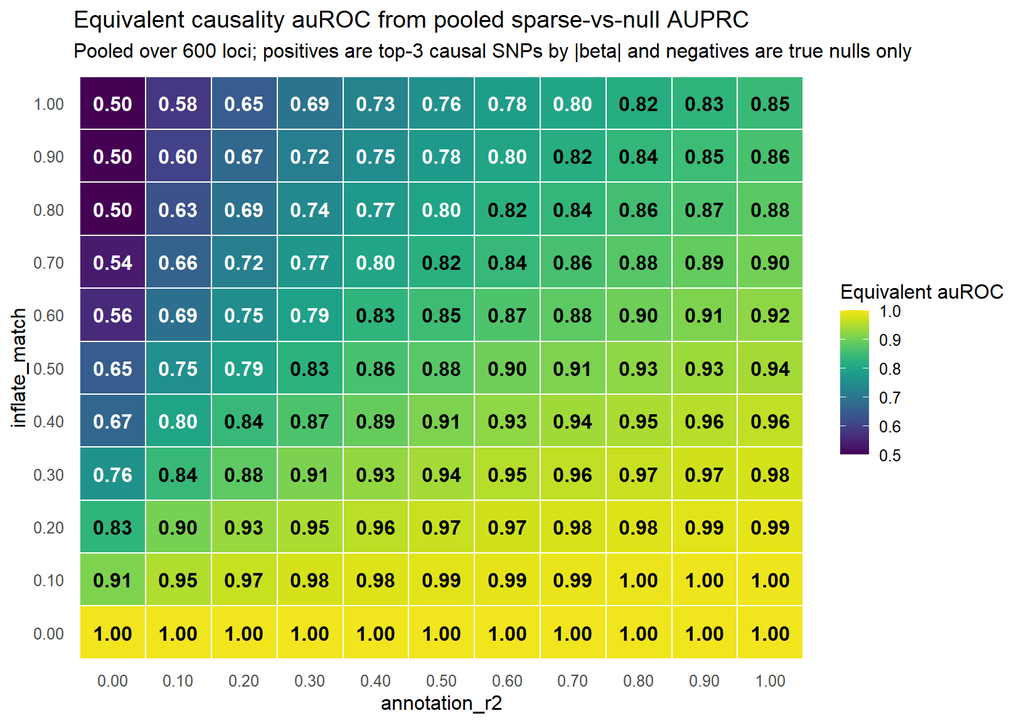

```r
plot_metric_heatmap(
  pooled_summary_tbl,
  value_col = "equivalent_causality_auroc",
  title = "Equivalent causality auROC from pooled sparse-vs-null AUPRC",
  subtitle = paste0(
    "Pooled over ", n_beta_draws,
    " loci; positives are top-", p_score_causality,
    " causal SNPs by |beta| and negatives are true nulls only"
  ),
  fill_label = "Equivalent auROC",
  option = "D",
  limits = c(0.5, 1),
  digits = 2
)
```

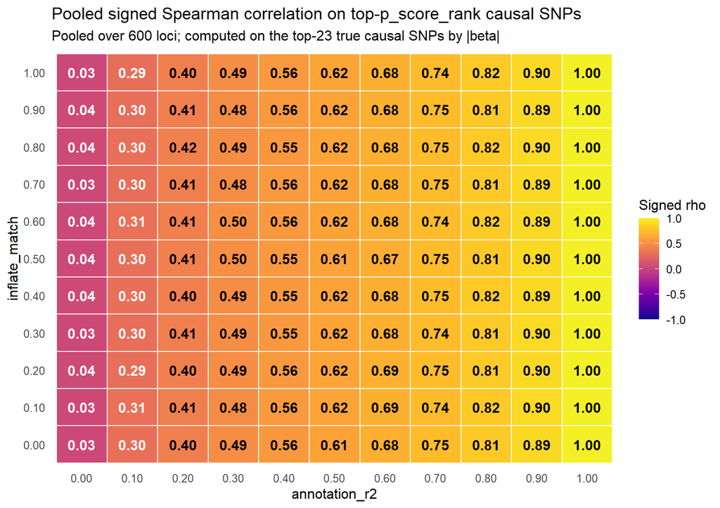

```r
plot_metric_heatmap(
  pooled_summary_tbl,
  value_col = "signed_spearman",
  title = "Pooled signed Spearman correlation on top-p_score_rank causal SNPs",
  subtitle = paste0(
    "Pooled over ", n_beta_draws,
    " loci; computed on the top-", p_score_rank,
    " true causal SNPs by |beta|"
  ),
  fill_label = "Signed rho",
  option = "C",
  limits = c(-1, 1),
  digits = 2
)
```

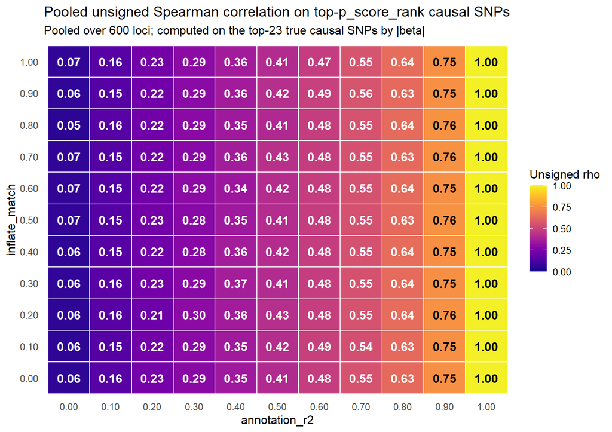

```r
plot_metric_heatmap(
  pooled_summary_tbl,
  value_col = "unsigned_spearman",
  title = "Pooled unsigned Spearman correlation on top-p_score_rank causal SNPs",
  subtitle = paste0(
    "Pooled over ", n_beta_draws,
    " loci; computed on the top-", p_score_rank,
    " true causal SNPs by |beta|"
  ),
  fill_label = "Unsigned rho",
  option = "C",
  limits = c(0, 1),
  digits = 2
)
```

# 11 Working Calibration Choice

The purpose of the heatmaps is to support a practical downstream choice, not to pretend that there is a single exact inverse map from AlphaGenome into this simulator. Our current working interpretation is:

- `inflate_match` should be very close to `1`
- `annotation_r2` should be moderate rather than high

For downstream studies, the working estimate we will carry forward is:

- `inflate_match in [0.95, 1.00]`
- `annotation_r2 = 0.30`

This choice reflects the following judgment:

- the causality panel is being used mainly to place `inflate_match`, and the realistic regime appears to be the nearly matched one rather than the artificially easy low-`inflate_match` regime;
- the coefficient-style panels are being used mainly to place `annotation_r2`, and a value around `0.30` gives a moderate but nontrivial alignment between annotation and true effect size, which is more believable than a near-perfect annotation generator.

# 12 Notes

- The simulator architecture is fixed at 3 sparse, 5 oligogenic, and 15 polygenic causal SNPs per locus.
- If `p_score_causality` is changed, the causality-positive set is always the top `p_score_causality` true causal SNPs by `|beta|`, capped at the number of true causal SNPs.
- If `p_score_rank` is changed, the rank-correlation set is always the top `p_score_rank` true causal SNPs by `|beta|`, capped at the number of true causal SNPs.
- The equivalent `auROC` conversion is a rough bridge for calibration, not a claim that the AlphaGenome and simulated tasks are exactly the same.